# Fractals in R: drawing plants

Arnau Muns Orenga

2018-04-17

# 1 Explanation

I’m trying to create some patterns of plants growing, based on [L-Systems](https://matap.dmae.upm.es/cursofractales/capitulo2/lparse/lparser.htm). L-System is a very efficient way to make drawings. It consists in two different actions: draw a straigh line and change the angle.

For example, if you want to draw a square you have to do: draw a straigh line of any length, turn 90 degrees (without drawing), draw another straigh line of the same length, turn 90 degrees in the same direction, draw, turn and draw again. In terms of a L-System, denoting F as the action of drawing a line of length d and + as turning 90 degrees right, the whole process to draw a square can be represented as **F+F+F+F**.

There are four important parameters in L-Systems:

- The seed of the drawing, called **axiom**
- The substitutions to be applied iteratively, called **rules**
- How many times to apply substitutions, called **depth**
- **Angle** of each turning

In this document you will find the patterns I like the most. Feel free to try different combinations of the four rules to find your own patters.

## 1.1 Plant 1

```r
axiom="F"
rules=list("F"="FF-[-F-F+F+F]+[+F+F-F-F]")
angle=22.5
depth=4
```

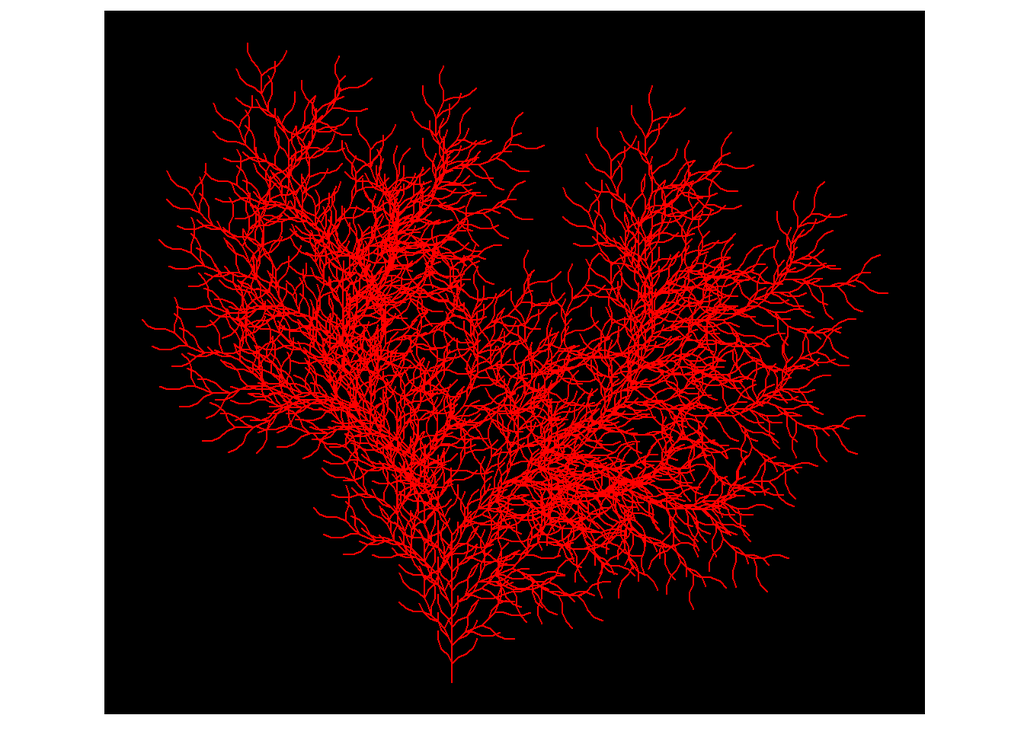

## 1.2 Plant 2

```r
axiom="X"
rules=list("X"="F[+X][-X]FX", "F"="FF")
angle=26
depth=7
```

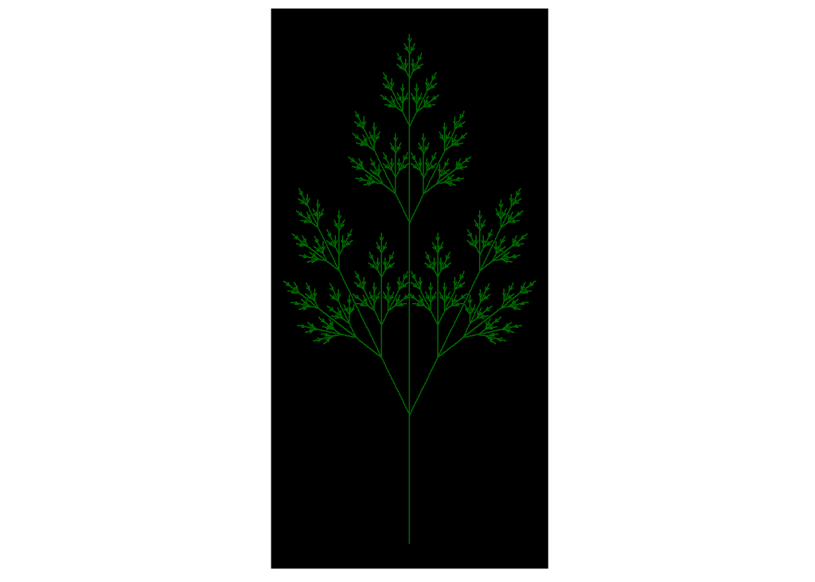

## 1.3 Plant 3

```r
axiom="X"
rules=list("X"="F[+X]F[-X]+F+X", "F"="FF")
angle=25
depth=7
```

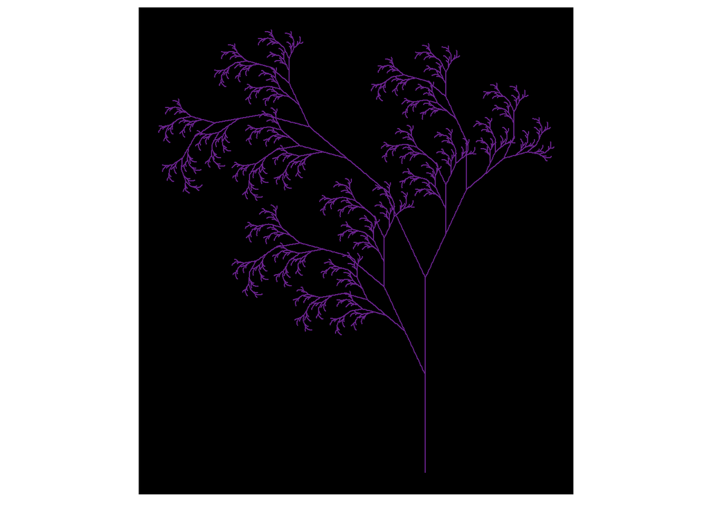

## 1.4 Plant 4

```r
axiom="X"
rules=list("X"="F-[[X]+X]+F[-FX]-X", "F"="FF")
angle=22.5
depth=6
```

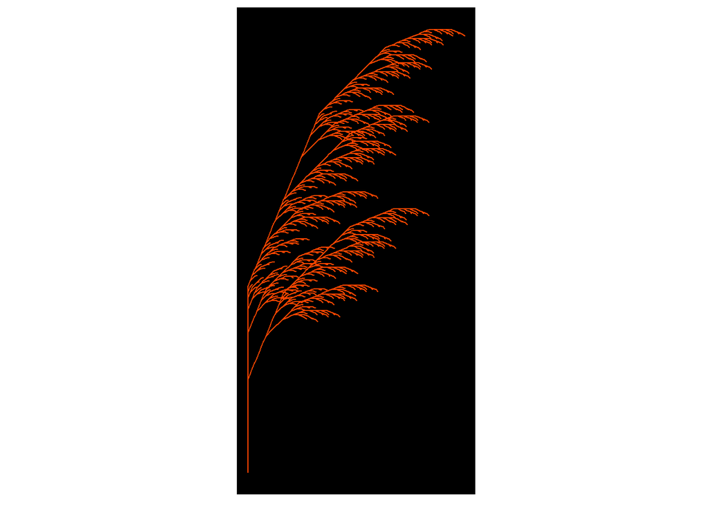

## 1.5 Plant 5

```r
axiom="F"
rules=list("F"="F[+F][-F]F[-F][+F]F")
angle=24
depth=5
```

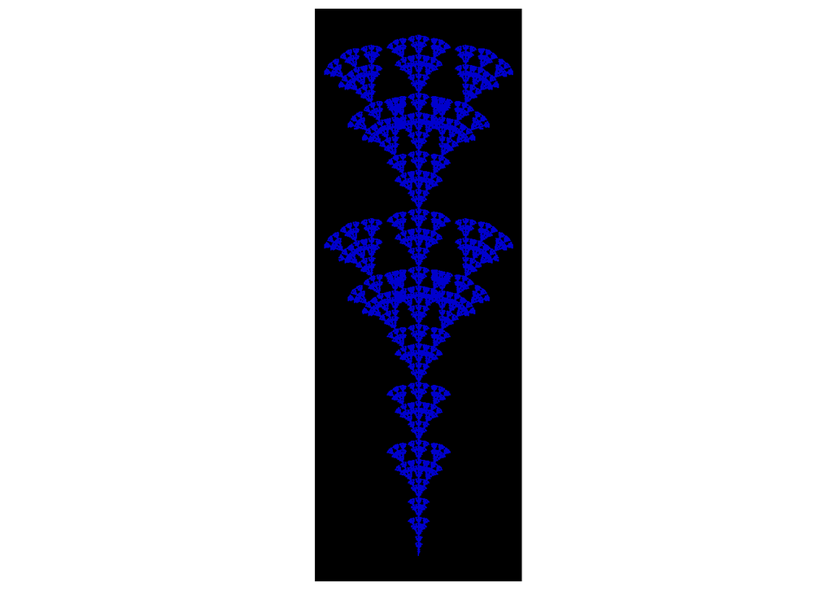

A work by [Arnau Muns Orenga](https://github.com/ArnauMunsOrenga/)

*arnau.muns12@gmail.com*